# Principles of mass spectrometry

Dr. Ahmad Redaa

2025-01-26

# Principles of Mass Spectrometry

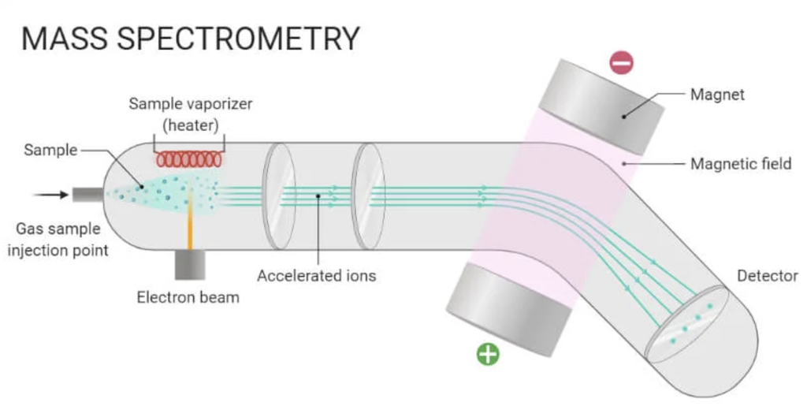

Source: [https://microbenotes.com](https://www.wikidoc.org/index.php/Mass_spectrometry)

- **Definition:** Mass spectrometry is an analytical technique used to measure the mass-to-charge ratio of ions.
- **Importance:** commonly use for analysis of isotopes and geochemical data.

# Basic Principles of Operation

1. **Ionization:** Converts atoms/molecules into ions.
2. **Acceleration:** Ion beam is accelerated to uniform kinetic energy.
3. **Mass-to-Charge Separation:** Analyzer separates ions based on their mass-to-charge ratio.
4. **Detection:** Measures the abundance of separated ions to generate a mass spectrum.
5. **High Vacuum Conditions:** Reduces ion collisions, ensuring accurate measurements.

# Components of Mass Spectrometers

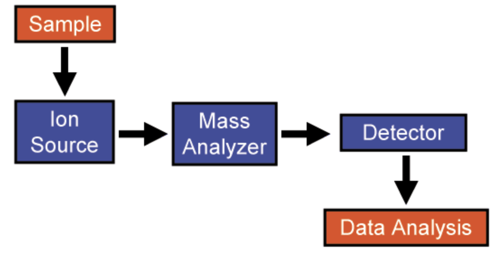

Source: [WikiDoc](https://www.wikidoc.org/index.php/Mass_spectrometry)

1. **Ionizer (Ion Source):** Generates ions from the sample.
2. **Mass Analyzer:** Separates ions by mass-to-charge ratio.
3. **Ion Detector:** Captures and quantifies ions.
4. **Vacuum System:** Maintains high vacuum for accurate ion movement.
5. **Data System:** Processes and analyzes mass spectra.

# Types of Mass Analyzers

1. **Quadrupole Analyzer:** Uses oscillating electric fields to filter ions.
2. **Time-of-Flight (TOF):** Measures time for ions to travel a fixed distance.
3. **Ion Trap Analyzer:** Captures and manipulates ions in a confined space.
4. **Magnetic Sector Analyzer:** Deflects ions using a magnetic field based on mass.
5. **FT-ICR:** Ultra-high resolution using ion cyclotron resonance.

# Sample Introduction Methods

- **Gas:** Coupled with gas chromatography.
- **Liquid:** Coupled with liquid chromatography.
- **Solid:** Direct injection (e.g., laser ablation).

# Ionization Techniques

1. **Electron Ionization (EI):** Example: Magnetic sector instruments.
2. **Chemical Ionization (CI):** Example: Quadrupole instruments.
3. **Electrospray Ionization (ESI):** Example: TOF instruments.
4. **Matrix-Assisted Laser Desorption/Ionization (MALDI):** Example: MALDI-TOF instruments.

# Ion Detection Systems

1. **Electron Multipliers:** Amplifies ion signals.
2. **Faraday Cups:** Measures ion current directly.
3. **Array Detectors:** Simultaneous detection of multiple ions.

# Mass Spectra Interpretation

1. **Mass-to-Charge Ratio (m/z):** Identifies ions.
2. **Isotope Patterns:** Reveals isotope composition.
3. **Fragmentation Patterns:** Analyzes molecular structure.
4. **Molecular Ion Peaks:** Indicates molecular weight.

# Quantitative Analysis

1. **Calibration Methods:** Relates signal intensity to ion concentration.
2. **Internal Standards:** Enhances measurement precision.
3. **Isotope Dilution:** Ensures accurate quantification.

# Limitations and Challenges

1. **Matrix Effects:** Interference from sample composition.
2. **Isobaric Interferences:** Overlapping ions with similar m/z.
3. **Instrument Sensitivity:** Detecting low-abundance ions.

# References and Further Reading

- Reference: [Fiveable Isotope Geochemistry Study Guide](https://library.fiveable.me/isotope-geochemistry/unit-4)
- Further Reading: *Radiogenic Isotope Geology* by Dickin